O modelo de regressão linear é bastante utilizado na predição de variáveis contínuas, onde há uma ou mais variáveis independentes e uma variável dependente (em que se busca comprovar uma hipótese sobre seu comportamento). Este é um modelo bastante simples de ser aplicado e um dos primeiros a ser ensinado nas aulas de econometria. Porém, apesar de sua simplicidade, para que o modelo gere resultados confiáveis, algumas premissas precisam ser satisfeitas sendo elas:

1. Não existência de multicolinearidade entre as variáveis dependentes.
2. Não existência de autocorrelação na variável dependente.
3. Não existência de padrão no comportamento dos resíduos, ou seja, não ocorre heterocedasticidade.
4. Distribuição normal dos resíduos.
5. Média aritmética dos residuos deve ser igual a zero.

Satisfazendo estas premissas, o modelo pode ser execuato e as conclusões geradas serão confiáveis para permitir a tomada de decisão. Neste post, irei analisar a premissa nº 3 e 4, que trata dos resíduos gerados no modelo de regressão linear. Para isso, vou usar uma base de dados que apresenta o preço da cana de açucar como variável independente e a área plantada (em hectares) de cana de açucar, que será a variável dependente.

A ideia deste exemplo é analisar, através de um modelo de regressão linear simples, a elasticidade da oferta da cana de açucar em função do preço de venda. A hipótese é que existe elasticidade na oferta, onde a área plantada aumenta conforme o preço também aumenta. Porém para validar esta elasticidade, é necessário comprovar, através da regressão, que as variáveis possuem correlação e a validade das premissas 3 e 4 ajudarão a apoiar esta conclusão.

Para este exemplo, serão utilizados os pacotes abaixo:

```r
library(tidyverse)
library(lmtest)
library(corrplot)
library(readxl)
library(gridExtra)
library(ggthemes)

# Definindo tema padrão dos gráficos
theme_set(theme_economist())
```

A base de dados apresenta 34 registros com informação de área plantada e preço da cana de açucar, ambos já transformados em logarítmo natural. Abaixo consta uma amostra da base de dados com os valores do preço da cana de açucar e área plantada.

Tabela 1: Amostra dos dados

| periodo | area | valor |
| --- | --- | --- |
| 1 | 29 | 0.075 |
| 2 | 71 | 0.115 |
| 3 | 42 | 0.101 |
| 4 | 90 | 0.110 |
| 5 | 72 | 0.110 |
| 6 | 57 | 0.132 |
| 7 | 44 | 0.142 |
| 8 | 61 | 0.210 |
| 9 | 60 | 0.188 |
| 10 | 70 | 0.196 |

O modelo de regressão linear proposto para este exemplo é definido pela equação abaixo.

$$lnY_t = \beta_1+\beta_2 (lnX_t) + U_t$$

Onde:

$Y_t$ = área plantada no ano t (em hectares), em log natural

$X_t$ = preço no ano t, em log natural

A utilização de logarítmo natural ocorre por conta de que esta transformação faz com que variações de um período para o outro (e.g. período 1 para o período 2) sejam intepretadas como variação percentual. Desta forma, no exemplo em questão, tem-se no período 1 os valores de (área = 29; valor = 0.075) e no período 2 tem-se (área = 71; valor = 0.115), cada um com as respectivas variações (área = 42; valor = 0.04). Estas variações podem ser intepretadas como variação percentual ao invés de variação bruta e essa mudança é essencial para a análise de elasticidade, que se baseia em variações percentuais nas variáveis independentes e dependentes.

Abaixo consta um exemplo que mostra como variações brutas podem ser interpretadas como variações percentuais quando os valores estão transformados em logarítmo natural. Para mais informações veja [artigo 1](https://people.duke.edu/~rnau/411log.htm) [artigo 2](https://dev.to/rokaandy/logarithmic-transformation-in-linear-regression-models-why-when-3a7c).

Tabela 2: Valores com log na base e

| Valor | Crescimento | Log.natural | Delta |
| --- | --- | --- | --- |
| 100 | - | 4.605 | - |
| 105 | 5.00% | 4.654 | 4.88% |
| 112 | 6.67% | 4.718 | 6.45% |
| 120 | 7.14% | 4.787 | 6.9% |

Ao tentar criar esta mesma tabela com outros logarítmos (e.g. base 2 ou base 10), não se alcança os mesmos resultados. Portanto, esta interpretação e transformação só faz sentido com logaritmo natural.

Tabela 3: Valores com log na base 2

| Valor | Crescimento | Log.natural | Delta |
| --- | --- | --- | --- |
| 100 | - | 6.644 | - |
| 105 | 5.00% | 6.714 | 7.04% |
| 112 | 6.67% | 6.807 | 9.31% |
| 120 | 7.14% | 6.907 | 9.95% |

Tabela 4: Valores com log na base 10

| Valor | Crescimento | Log.natural | Delta |
| --- | --- | --- | --- |
| 100 | - | 2.000 | - |
| 105 | 5.00% | 2.021 | 2.12% |
| 112 | 6.67% | 2.049 | 2.8% |
| 120 | 7.14% | 2.079 | 3% |

Após entender um dos motivos da transformação em log, podemos continuar com a construção do modelo para validar as premissas dos resíduos. O gráfico abaixo mostra o comportamento das variáveis estudadas e a curva de regressão.

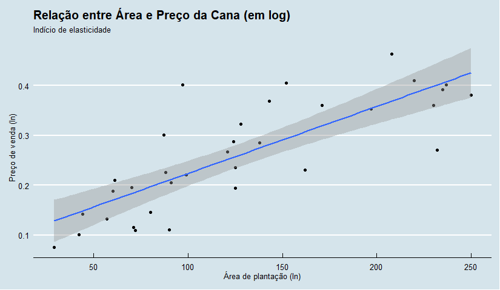

```r
dados_2 %>%
  ggplot(aes(x=area,y=valor))+
  geom_point()+
  geom_smooth(method = "lm",se = T)+
  labs(
    title = "Relação entre Área e Preço da Cana (em log)",
    subtitle= "Indício de elasticidade",
    x = "Área de plantação (ln)",
    y = "Preço de venda (ln)"
  )
```

Nota-se que as variáveis possuem correlação linear, ou seja, há elasticidade de oferta neste mercado. Abaixo consta o sumário do modelo de regressão:

```r
model <- lm(area~valor,data = dados_2)

summary(model)
```

```
##
## Call:
## lm(formula = area ~ valor, data = dados_2)
##
## Residuals:
##     Min      1Q  Median      3Q     Max
## -97.901 -25.544  -8.999  24.135  99.908
##
## Coefficients:
##             Estimate Std. Error t value Pr(>|t|)
## (Intercept)     2.54      17.77   0.143    0.887
## valor         479.18      62.95   7.612 1.13e-08 ***
## ---
## Signif. codes:  0 '***' 0.001 '**' 0.01 '*' 0.05 '.' 0.1 ' ' 1
##
## Residual standard error: 39.65 on 32 degrees of freedom
## Multiple R-squared:  0.6442, Adjusted R-squared:  0.6331
## F-statistic: 57.95 on 1 and 32 DF,  p-value: 1.131e-08
```

A equação de regressão gerada pelo modelo é definida como: $lnY_t = 2.54 + 479.18 (lnX_t) + U_t$

O coeficiente de correlação (R²) ficou em 64%, o R² ajustado em 63% e um valor-p abaixo de 0.05, o que mostra uma correlação significativa entre as variáveis. Porém, não basta estes resultados para indicar que o modelo é confiável, é preciso analisar as premissas com relação aos resíduos para poder confiar nos resultados gerados.

A tabela abaixo apresenta uma amostra dos resíduos gerados:

Tabela 5: Resíduos gerados pelo modelo

| x |
| --- |
| -9.603 |
| 13.405 |
| -8.974 |
| 34.602 |
| 16.960 |
| -9.025 |
| -26.480 |
| -41.957 |
| -32.750 |
| -26.434 |

É interessante combinar os resíduos gerados com os dados originais do modelo em um mesmo data.frame, para facilitar na construção de gráficos.

Os gráficos abaixo apresentam o comportamento dos resídos do modelo. O primeiro com a distribuição dos resíduos em um histograma e o segundo com os resíduos ao longo dos períodos analisados.

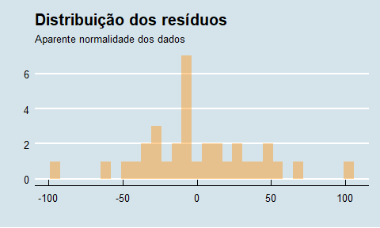

[figure not shown]

2. Aplique o teste de Durbin Watson, escrevendo as hipóteses e testando a autocorrelação. Use um nível de significância de 5%.

R: Abaixo há a aplicação do teste DW.

```
##
##  Durbin-Watson test
##
## data:  model
## DW = 1.4745, p-value = 0.04089
## alternative hypothesis: true autocorrelation is greater than 0
```

De maneira resumida, o valor-p foi de 0.04089 e o valor dw de 1.4745. Neste teste, usa-se o valor dw para gerar a conclusão do teste. Antes, é preciso trazer os intervalos para comparar com o dw. Para encontrar o intervalor, use esta [tablea](http://www.portalaction.com.br/analise-de-regressao/33-diagnostico-de-independencia) específica do teste.

**dl** = 1.35

**du** = 1.49

O valor dw (1.4745) ficou entre os limites dl e du, o que não permite gerar conclusões sobre o comportamento dos resíduos.

3. Aplique o teste Breusch Godfrey (a.k.a teste LM) escrevendo as hipóteses. Teste a autocorrelação com nível de significância de 5% e escreva a conclusão.
4. Aplique o teste Q e comente os resultados.